# Kickstarter Project Analysis

DATA501 Foundations of Data Science Using R

Jake Warmflash

2024-06-13

## ABSTRACT

Kickstarter campaigns can be placed into categories based on the nature of the product or service being pitched. It was found that Dance, Comics, and Theater projects are much more likely to be successfully funded than Food, Journalism, or Technology projects. It was also shown that December has the least amount of campaigns launched. Finally, it was shown that the number of backers has no affect on the amount pledged per backer. Based on this information, a prospective Kickstarter creative trying to fund their project on the site should choose one of the more successful project categories and launch it in December where this is less competition. They should try to capture as many backers as possible to increase the likelihood of a successful campaign.

## INTRODUCTION

Kickstarter is a public funding platform for creative projects. From crafts to games to art to fashion, any type of project can be put up on the website to try an attract backers to donate, in order to fund and create the product or service. Projects are created with a specific funding goal that is set out to be reached in the given time frame. If the project does not reach its goal, all pledges are cancelled and all money is returned. Some successful products originally launched from Kickstarter include the card game Exploding Kittens, the Reading Rainbow reboot educational service (rebranded as LeVar Burton Kids) and their educational program Skybrary, the Peak Design Everyday Backpack, a backpack for photographers and travelers, and Yooka-Laylee, a video game made by former developers from the company Rareware, attempting to recapture and recreate the type of 3D platformer popular in the late 90s.

Though there are many successful projects launched from this site, many projects fail to reach their goal, killing the project before it begins. Even a successful campaign does not always equate to a realized product so backers are warned that their donations are simply that and are not preorders. There are no guarantees to get the product or for the product to even end up being created. Because of this, it is risky to back a project. Backers should only support projects they believe in.

The main questions this analysis seeks to answer are which project categories are most likely to be successful? When should one launch their project to get the most eyes on their campaign? Are there specific high pledge backers that can be targetted? These questions serve to help new creators when deciding when and how to start their own Kickstarter campaign.

## DATA AND METHODOLOGY

This dataset has been provided by Jonathan Leland via ICPSR, which details all Kickstarter projects since the site’s founding in 2009. It includes names, project type, locations of the project, launch dates, deadline dates, project currency, goal in both original currency and in USD, amount pledged in both original currency and in USD, number of backers, state of the project (success, failure, cancelled, suspended), and URL to the project. For public use, name and URL have been removed for anonymity.

Data was collected via observational study pulling from the websites historical project data. Observational units were the campaigns launched. Sample size was the entire population of 506199 Kickstarter projects launched on the site spanning from the sites founding in 2009 to 2020. Because the entire population was included, there was no sampling methods and sampling bias that would accompany that.

For certain areas of study, some data was omitted. In this project, category, launch date, pledge amount, number of backers, and state of project were focused on. Data with zero backers or pledges were removed for some analysis to allow for certain modification and calculation. For some projects specific data points were not included or unavailable, which was accounted for when needed. Finally during some analysis, outlier data was removed to find specific models appropriate for explaining the data trends.

## RESULTS

Starting off, the data is wrangled to narrow it down to specific variable that will be studied. Variables are renamed and mutated from the original dataset for easier study.

First it is important to have an overview of the Kickstarter data. Which category of project were most popular?

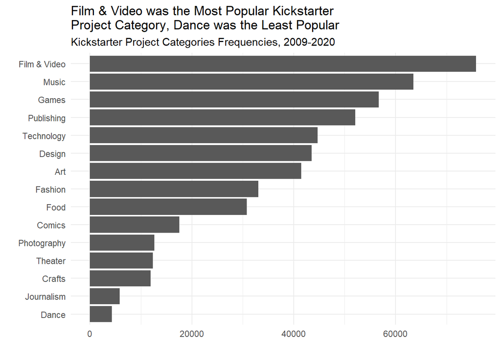

This graph shows the categories of all projects launched on Kickstarter, showing which categories were the most popular and which were the least popular. Certain categories of project are easier to create which may lead to more people starting a campaign for that category. When creating a project, it can be good to understand which categories the most other people have created projects for. But this doesn’t tell the whole story. Are all project categories just as likely to be successfully funded as one another? For this, it is important to look into the success rates of all projects based on their category.

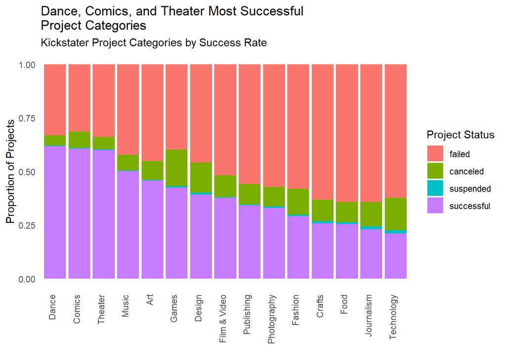

As shown in this graph, Dance, Comics, and Theater projects are much more likely to be successfully funded via Kickstarter campaign. Projects based on Food, Journalism, and Technology will have a much harder time being funded. Why is this? Is this difference in proportion actually significant?

**Hypothesis Test** Proportion of Successful Dance Projects vs Proportion of successful Technology Projects, 2 prop z test to compare two proportions

Ho:Proportion of Successful Dance Projects = Proportion of Successful Technology Projects Ha:Proportion of Successful Dance Projects > Proportion of Successful Technology Projects

**Assumptions**

1. Large enough sample size:

n1=4298 p1=.617 n2=44706 p2=.211

4298*.617=2651.866>10

4298*(1-.617)=1646.134>10

44706*.211=9432.966>10

44706*(1-.211)=35273.03>10

2. Independent Observations within groups:

Most likely projects do not affect other projects. There is however, a chance that multiple projects are made by the same people, which could have an effect on independence within groups. Assume independence for this situation.

3. Independent Groups:

Similarly to observations within groups, there is a chance that multiple projects are made by the same people, which could have an effect on independence between groups. Most likely, these projects are independent from each other. Assume independence for this situation.

4. 10% condition:

4298<.10*506199 44706<.10*506199

```
##
##  2-sample test for equality of proportions with continuity correction
##
## data:  c(0.617 * 4298, 0.211 * 44706) out of c(4298, 44706)
## X-squared = 3476.6, df = 1, p-value < 2.2e-16
## alternative hypothesis: greater
## 95 percent confidence interval:
##  0.3932697 1.0000000
## sample estimates:
## prop 1 prop 2
##  0.617  0.211
```

Based on this information, it can be understood that the differences in proportion of the most successful project category, dance, and the least successful project category, technology, are statistically significant. That means that dance projects truly are more likely to be funded in comparison to technology projects.

So, a creative can pick up that Dance and other high success project categories are more likely to be funded than others. Why is this? Dance and Theater projects can be put on and performed locally in a real life location. They are not products in the same way as a piece of technology or Fashion, and therefore do not need supply chains, production, and physical shipment for order fulfillment. Comics can be released and published online making distribution much easier, especially for a single author/artist. Technology products, on the other hand, can run into a large amount of issues after being successfully funded.

One of the most famous Kickstarter products is the Coolest Cooler, a cooler with a built in ice crushing blender, a removable waterproof USB speaker, USB charging ports, lights, bottle opener, plates, utensils, corkscrew, cutting board, and cupholders. The campaign, launched in July 2014, earned $13,285,226 from 62,642 backers. As production continued, complexity of shipping, logistics, and certification processes halted production, eventually leading to the dissolution of the company in 2019. More than 20,000 backers received only a $20 refund out of the around $200 they had backed for the projects.

Projects like these create distrust for physical products, making these types of projects harder to successfully fund. It is vital to think about the type of product and the likelihood of finding enough backers before embarking on a Kickstarter campaign.

While type of project is very important, are there any advantages one can find in when they launch their campaign?

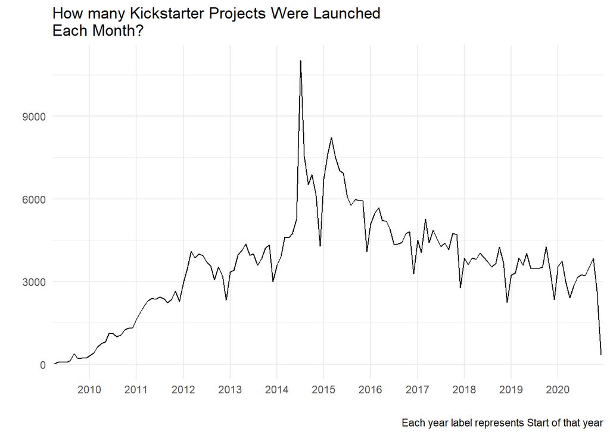

This graph shows the time trends on when Kickstarter projects were launched. Split by month, it can be seen that the peak of most projects launched took place in July of 2014(One of such projects being the Coolest Cooler). Interestingly, most years show similar patterns of a dip towards the end of the year as wll as a smaller dip around the late summer/early fall which is expanded and shown further in the next graph.

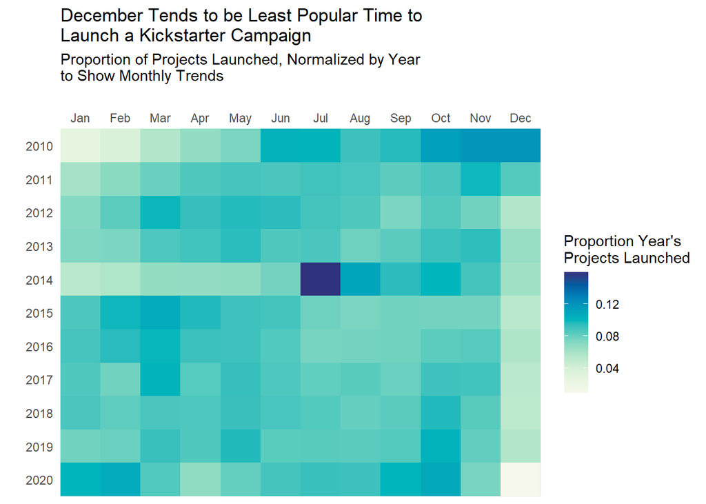

Here it can be seen the proportions of each year’s project launches by month. The dip in December of each year can be seen more clearly from this graph as well as small increases around March and October. Outlier years such as 2010 and 2014 can be seen easily in this graph.

For prospective creatives seeking to launch their Kickstarter campaign, they may want to launch during December, when they have less competition. Less other products means more attention can be given to their project, possibly leading to more backers and pledges. Even if one does not wish to launch in December, possibly due to the holiday season, they should avoid March and October as those months tend to have the most competition.

Now the question remains is July 2014 an outlier for the proportion of campaigns usually launched in July? Or is this indicative of July being a bad time to launch a Kickstarter campaign if one wishes to avoid as much competition?

**Hypothesis Test**

Compare Proportion of July 2014 to other July proportions to see if this month is an outlier. 1 Prop z Test to test proportion of July 2014 against real July Proportion.

Ho:p=.0926, The proportion of campaigns launched in July 2014 is equal to the expected proportion of campaigns launched in July of each year. Ha:p>.0926, The proportion of campaigns launched in July 2014 is greater than the expected proportion of campaigns launched in July of each year.

**Assumptions:**

1. Large Enough Sample Size:

n=All 2014 Campaigns=69150

p=.1594

69150*.1594=11022.51>10

69150*(1-.1594)=58127.49>10

2. Independent Observations:

Each campaign most likely is created by a different person or group. There is a chance that some of these campaigns were created by the same person or group, which would affect independence. For this situation assume independence.

3. Sample can’t be more than 10% of population:

11023<.1*506199

```
##
##  1-sample proportions test with continuity correction
##
## data:  69150 * 0.1594 out of 69150, null probability 0.0926
## X-squared = 3671.5, df = 1, p-value < 2.2e-16
## alternative hypothesis: true p is greater than 0.0926
## 95 percent confidence interval:
##  0.1571165 1.0000000
## sample estimates:
##      p
## 0.1594
```

It has been found that July 2014 truly is an outlier month in comparison to the usual proportion of campaigns launch in July. This specific month should not be used as reason for not launching a project on the site, as it was out of the ordinary.

Now that it is known what type of project to run and when to launch it, a good question to ask is whether a specific high-pledging backer can be targeted. Is it possible to attract a specific backer more likely to donate more money?

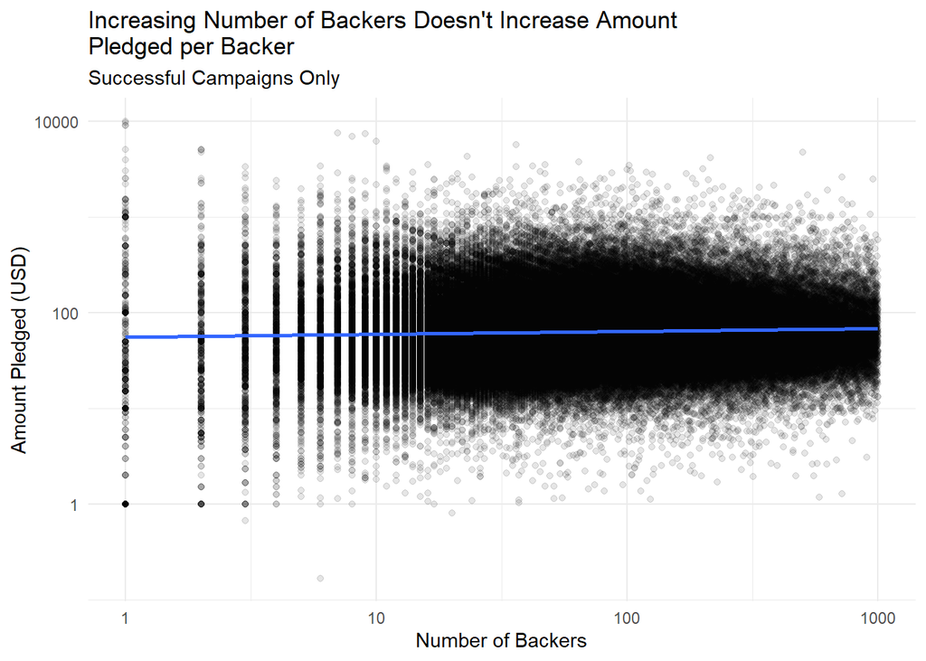

This graph looks at the amount of money pledged per backer explained by the number of backers the project has. It has been log transformed on both the x and y axis’s to highlight the trend. Finally, linear regression analysis has been done below.

```
##
## Call:
## lm(formula = log(PledgePerBacker) ~ log(NumBackers), data = ksPPB2)
##
## Residuals:
##     Min      1Q  Median      3Q     Max
## -4.4551 -0.4957 -0.0430  0.4531  5.1531
##
## Coefficients:
##                 Estimate Std. Error t value Pr(>|t|)
## (Intercept)     4.017049   0.006953  577.73   <2e-16 ***
## log(NumBackers) 0.029675   0.001575   18.85   <2e-16 ***
## ---
## Signif. codes:  0 '***' 0.001 '**' 0.01 '*' 0.05 '.' 0.1 ' ' 1
##
## Residual standard error: 0.7807 on 184563 degrees of freedom
## Multiple R-squared:  0.001921,   Adjusted R-squared:  0.001915
## F-statistic: 355.2 on 1 and 184563 DF,  p-value: < 2.2e-16
```

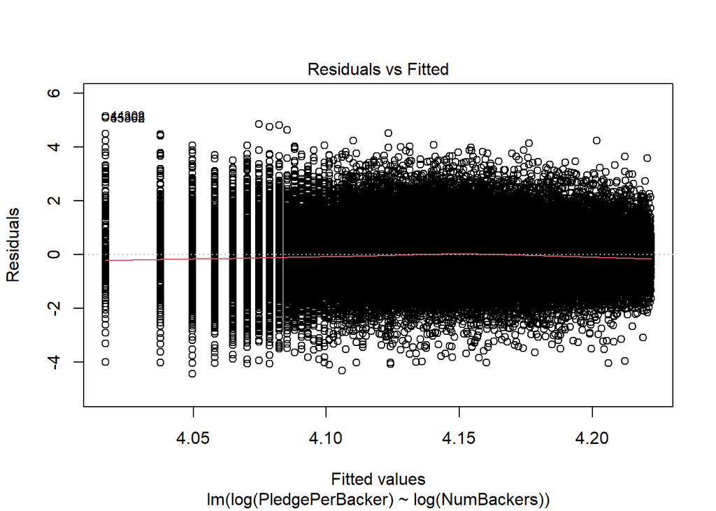

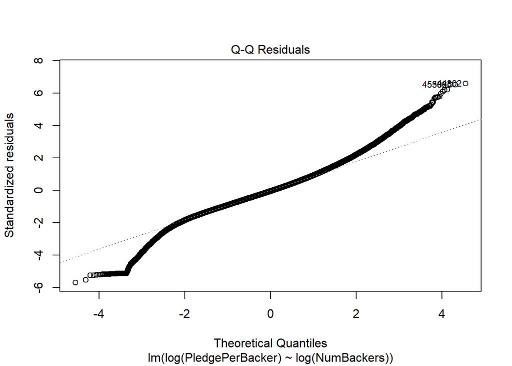

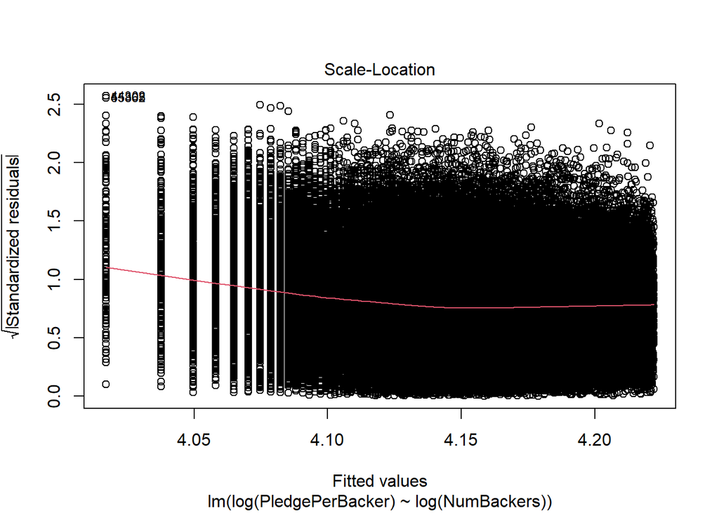

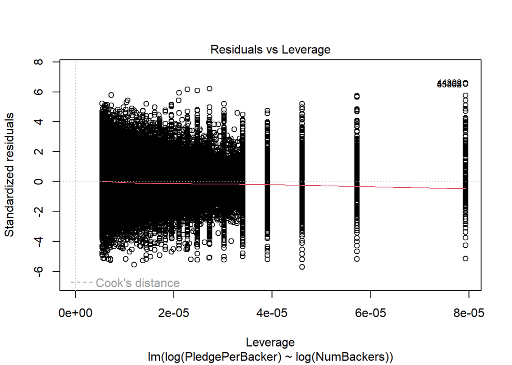

The model based on the logarithm of amount pledged per backer as explained by the logarithm of number of backers is shown here. A trendline formula of log(y)=4.017+0.0297*log(NumBackers) has been found. This line is not perfect, especially around explaining the projects with very low and very high number of backers. From this line we can see that there is almost no relationship between having a high or low amount of backers on the amount of money each backer will pledge. One does not attract high-donation backers via targeting many or few different people. Therefore, a campaign should just target as many backers as possible in order to generate the most pledges. The line has a very low R-squared value of 0.0019, making it not very explanatory of the dataset. There is a significant amount of variation within the data.

## CONCLUSION

Overall, Kickstarter is a good tool to find the funding for a project that may be hard to start on your own. When creating a project, creators may want to focus on one of the more easily fundable project categories such as Dance, Comics, or Theater. Creators may wish to launch projects in December where they have less competition and their project may stand out more. A project should have a reasonable goal while being unique enough to garner the attention needed to successfully find the appropriate backers. Projects should seek to find a wide audience to capture as many backers as they can to meet their funding goals.

One big limitation is the lack of accountability from projects. It is not stated whether or not the product was actually made following the Kickstarter campaign and whether backers ever saw a tangible product from what they backed. This data would allow the ability to see if certain types of projects are safer pledges and more likely to be actually made.

If this analysis were to be conducted again, it would be important to get more data about the projects, to try and find more about what makes a successful project. This would be difficult with keeping anonyminity, but certain words used and things offered in the individual project page likely have an imput on whether the project is successfully funded. This type of information would allow better understanding of what goes into making a successful Kickstarter campaign.